# State MSM Profile: **California**

#### Vallejo-Fairfield Metropolitan Statistical Area

The Vallejo-Fairfield MSA had a population of 3,126 MSM, or 0.4% of all MSM in California. Of the 156,933 adult men in Vallejo-Fairfield, an estimated 2.0% were MSM.

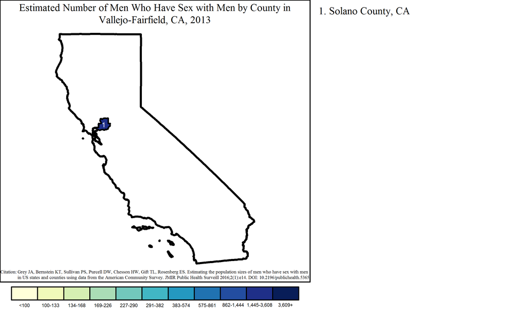

Note: Range cutpoints for the map are based on the distribution of MSM among all counties in the United States.

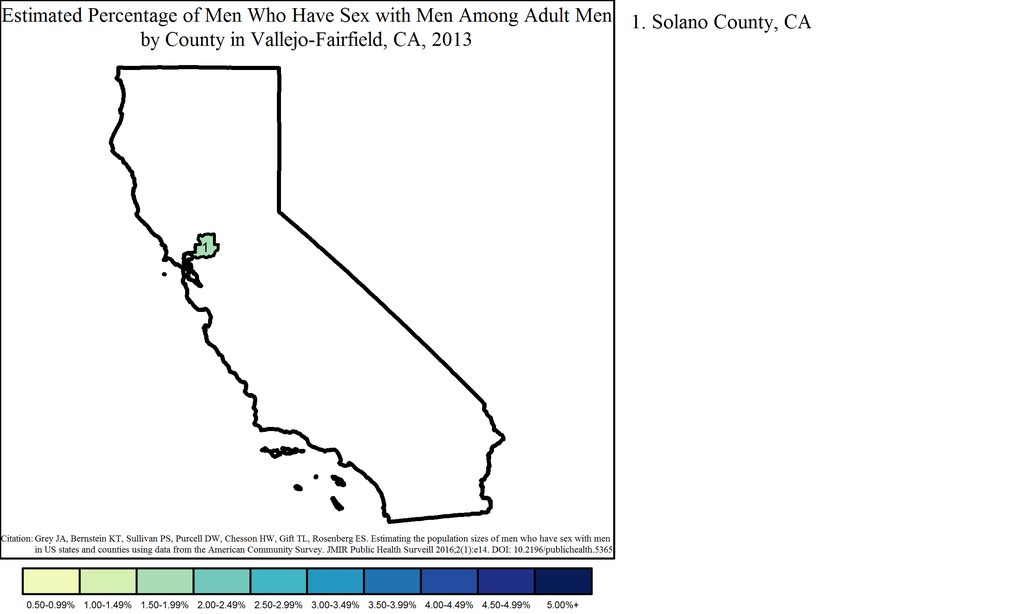

#### Modesto Metropolitan Statistical Area

The Modesto MSA had a population of 2,851 MSM, or 0.4% of all MSM in California. Of the 181,332 adult men in Modesto, an estimated 1.6% were MSM.

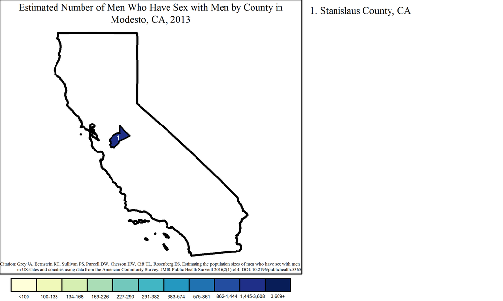

Note: Range cutpoints for the map are based on the distribution of MSM among all counties in the United States.

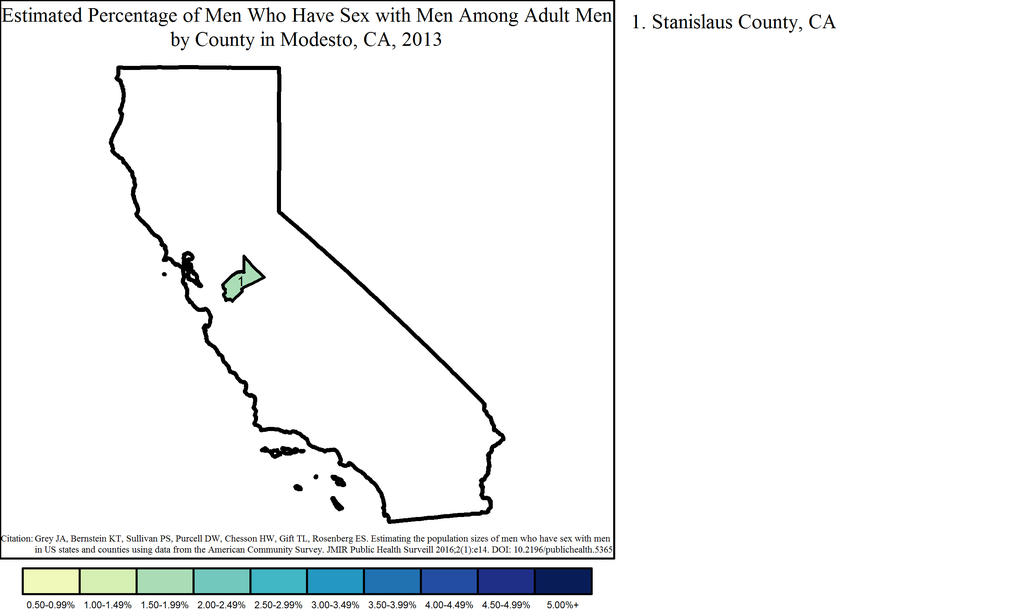

#### San Luis Obispo-Paso Robles-Arroyo Grande Metropolitan Statistical Area

The San Luis Obispo-Paso Robles-Arroyo Grande MSA had a population of 2,742 MSM, or 0.3% of all MSM in California. Of the 113,037 adult men in San Luis Obispo-Paso Robles-Arroyo Grande, an estimated 2.4% were MSM.

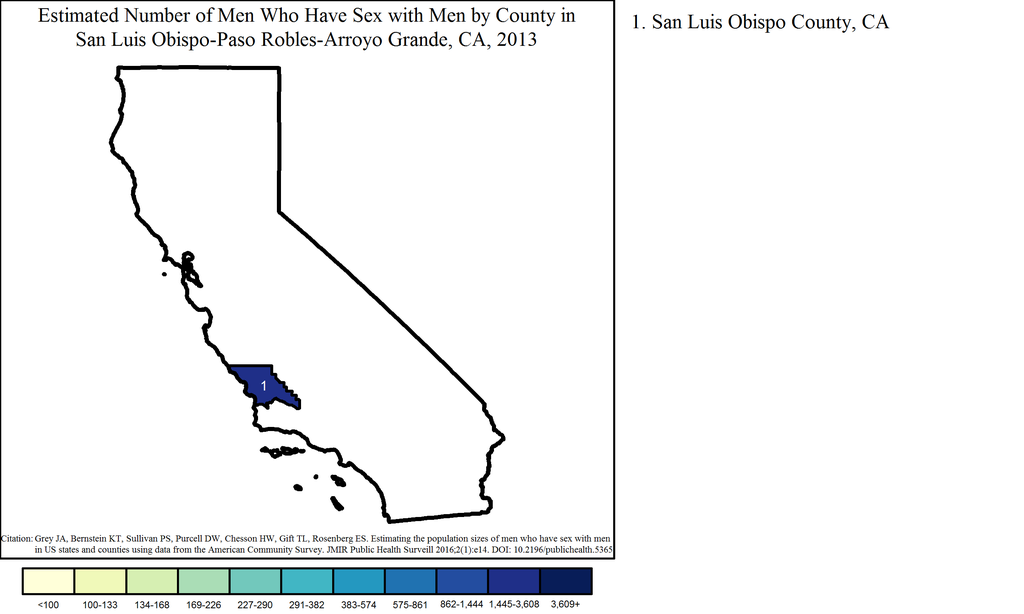

Note: Range cutpoints for the map are based on the distribution of MSM among all counties in the United States.

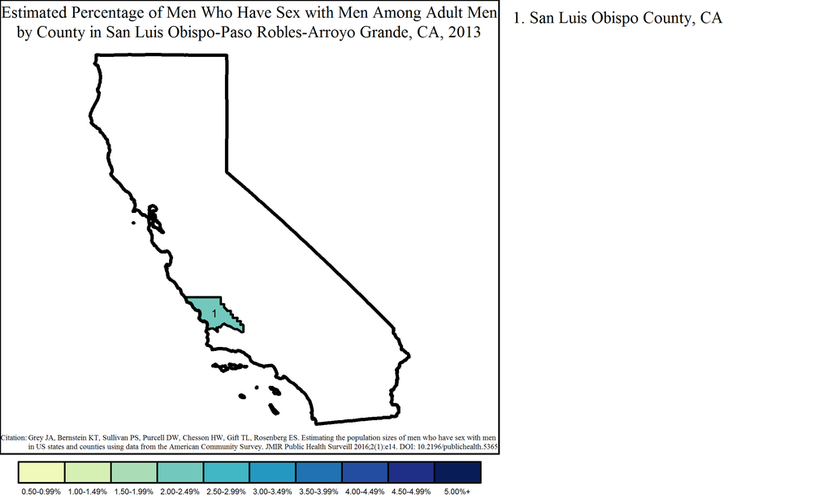

#### Visalia-Porterville Metropolitan Statistical Area

The Visalia-Porterville MSA had a population of 2,564 MSM, or 0.3% of all MSM in California. Of the 150,500 adult men in Visalia-Porterville, an estimated 1.7% were MSM.

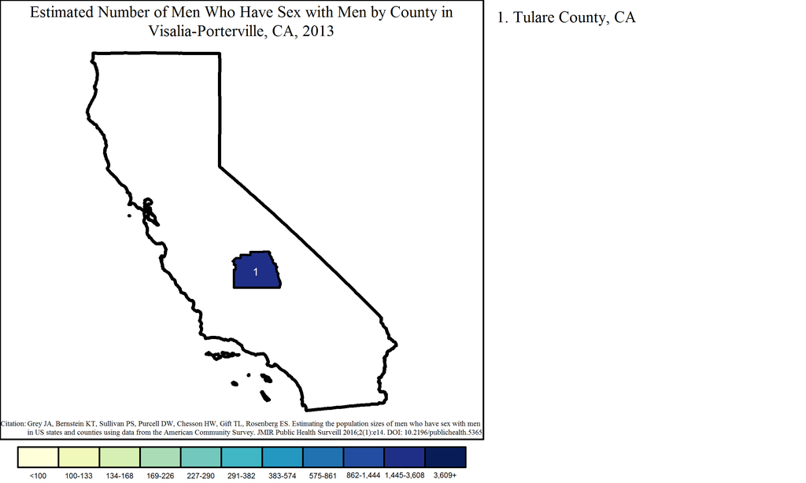

Note: Range cutpoints for the map are based on the distribution of MSM among all counties in the United States.

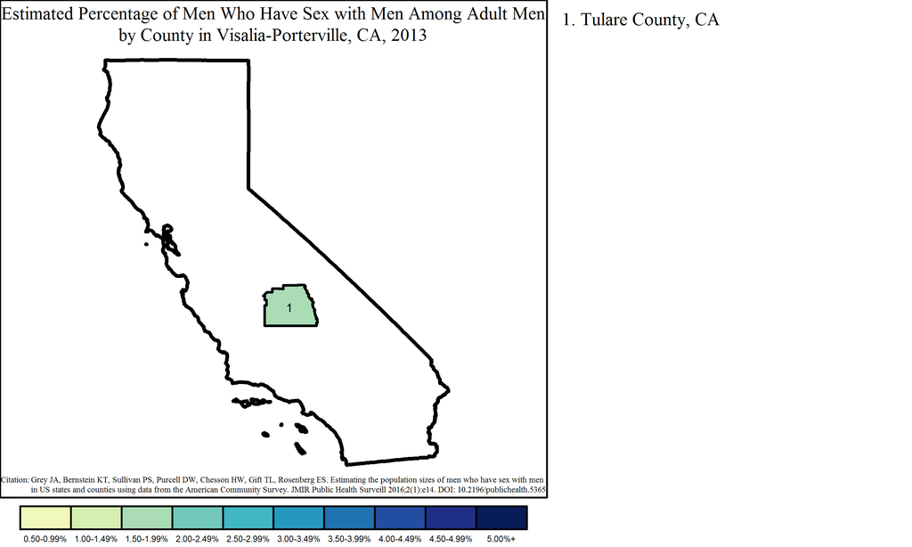

#### Chico Metropolitan Statistical Area

The Chico MSA had a population of 1,768 MSM, or 0.2% of all MSM in California. Of the 85,820 adult men in Chico, an estimated 2.1% were MSM.

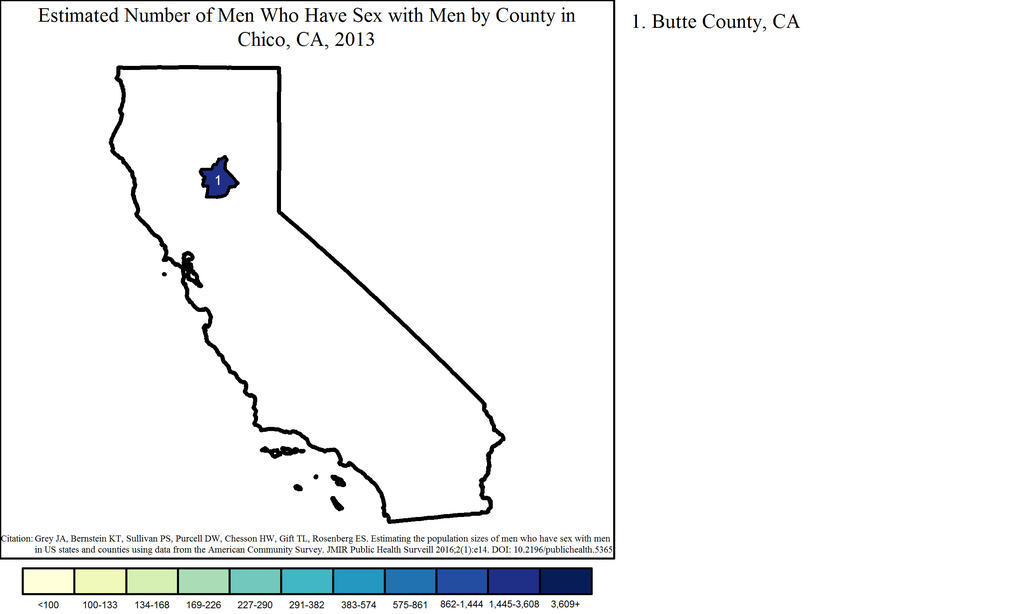

Note: Range cutpoints for the map are based on the distribution of MSM among all counties in the United States.

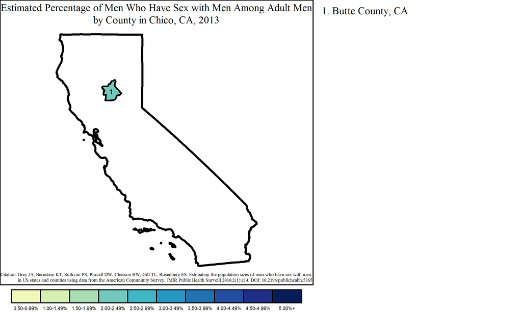

#### Merced Metropolitan Statistical Area

The Merced MSA had a population of 1,439 MSM, or 0.2% of all MSM in California. Of the 89,216 adult men in Merced, an estimated 1.6% were MSM.

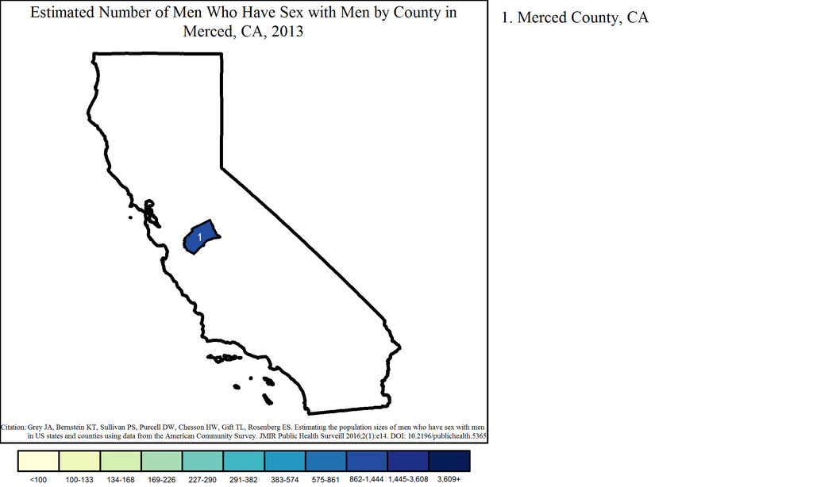

Note: Range cutpoints for the map are based on the distribution of MSM among all counties in the United States.

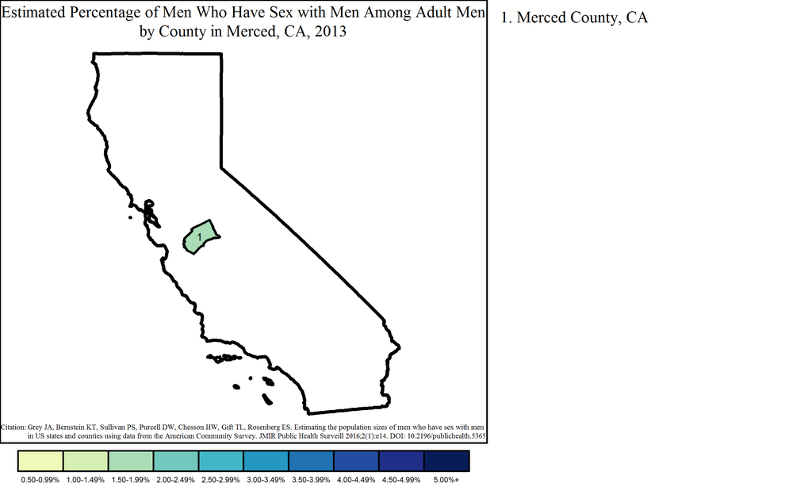

#### Yuba City Metropolitan Statistical Area

The Yuba City MSA had a population of 1,361 MSM, or 0.2% of all MSM in California. Of the 59,805 adult men in Yuba City, an estimated 2.3% were MSM.

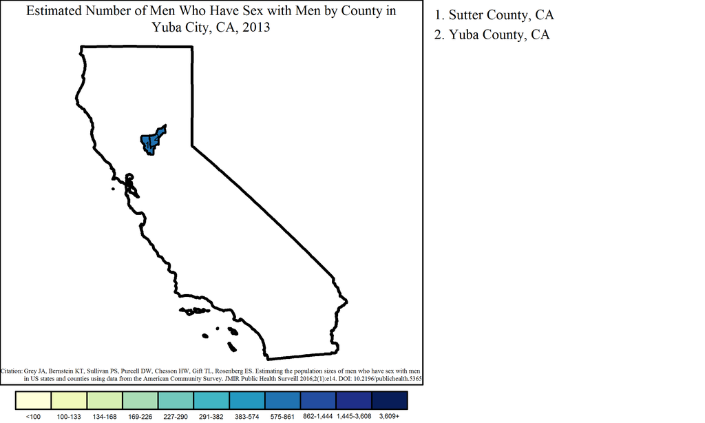

Note: Range cutpoints for the map are based on the distribution of MSM among all counties in the United States.

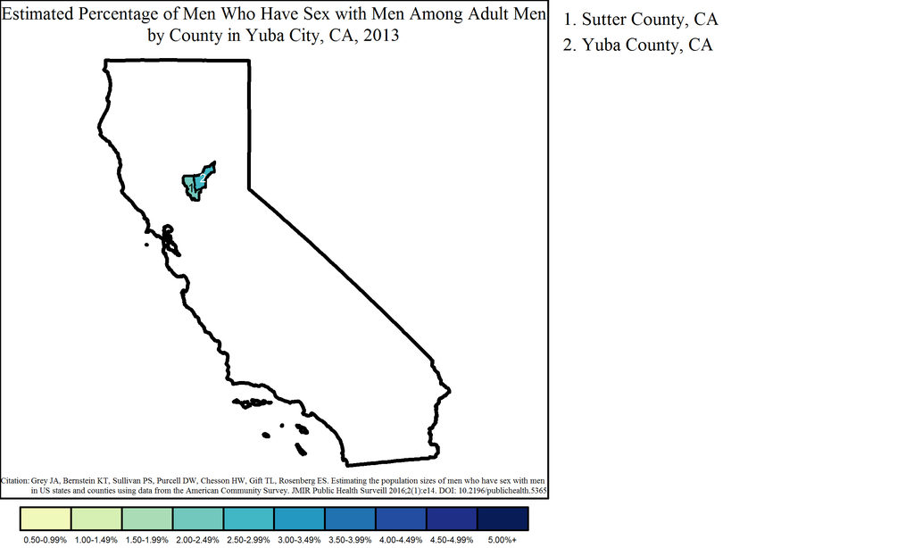

#### Napa Metropolitan Statistical Area

The Napa MSA had a population of 1,297 MSM, or 0.2% of all MSM in California. Of the 52,729 adult men in Napa, an estimated 2.5% were MSM.

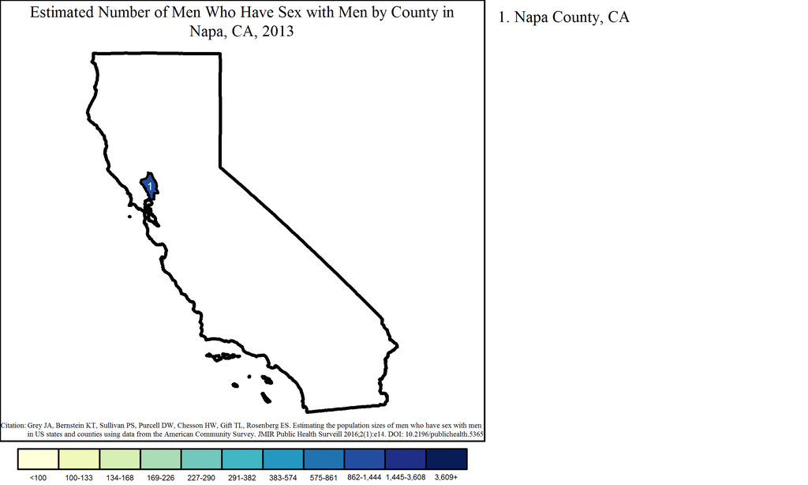

Note: Range cutpoints for the map are based on the distribution of MSM among all counties in the United States.

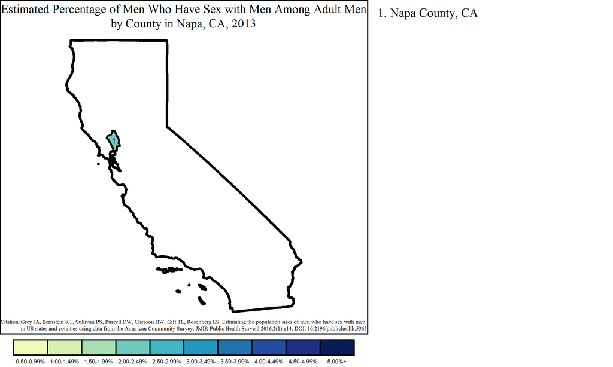

#### Hanford-Corcoran Metropolitan Statistical Area

The Hanford-Corcoran MSA had a population of 1,252 MSM, or 0.2% of all MSM in California. Of the 63,697 adult men in Hanford-Corcoran, an estimated 2.0% were MSM.

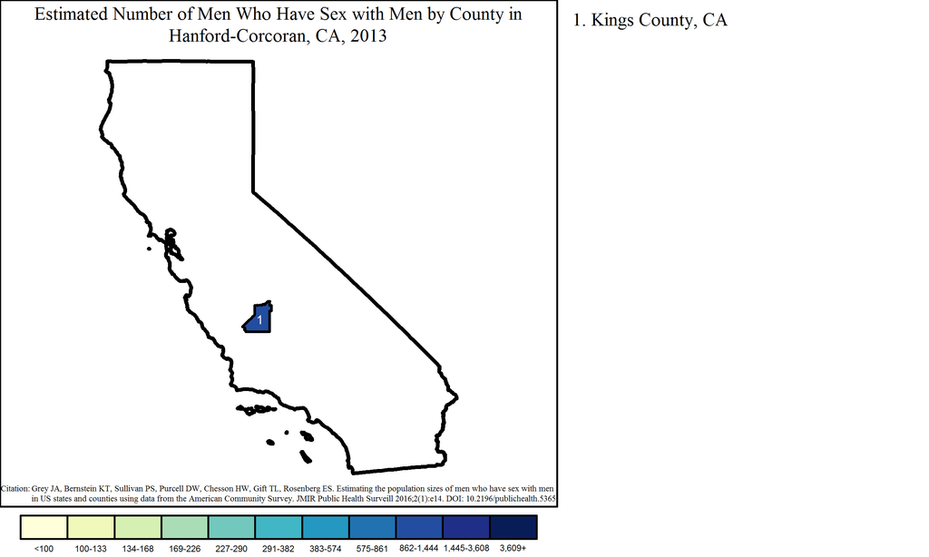

Note: Range cutpoints for the map are based on the distribution of MSM among all counties in the United States.

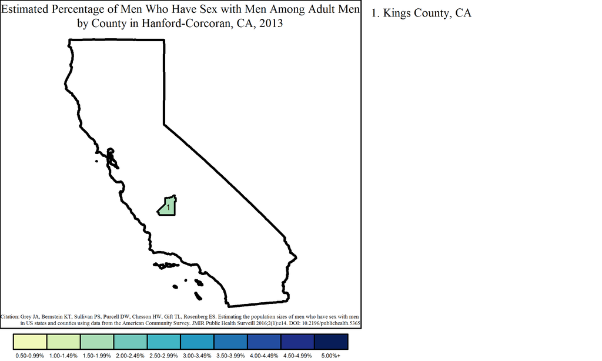

#### Redding Metropolitan Statistical Area

The Redding MSA had a population of 1,249 MSM, or 0.2% of all MSM in California. Of the 67,090 adult men in Redding, an estimated 1.9% were MSM.

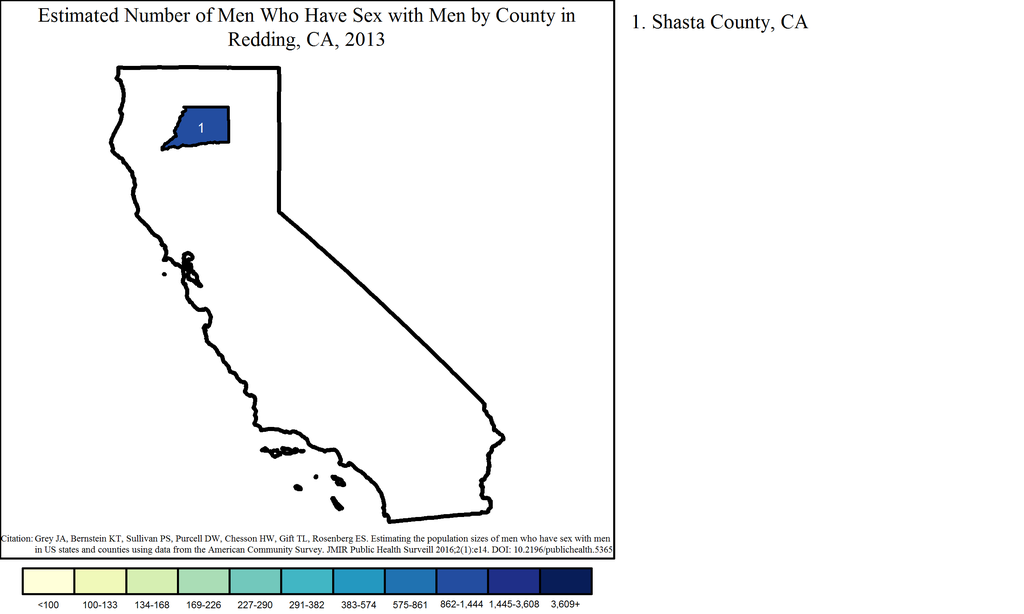

Note: Range cutpoints for the map are based on the distribution of MSM among all counties in the United States.

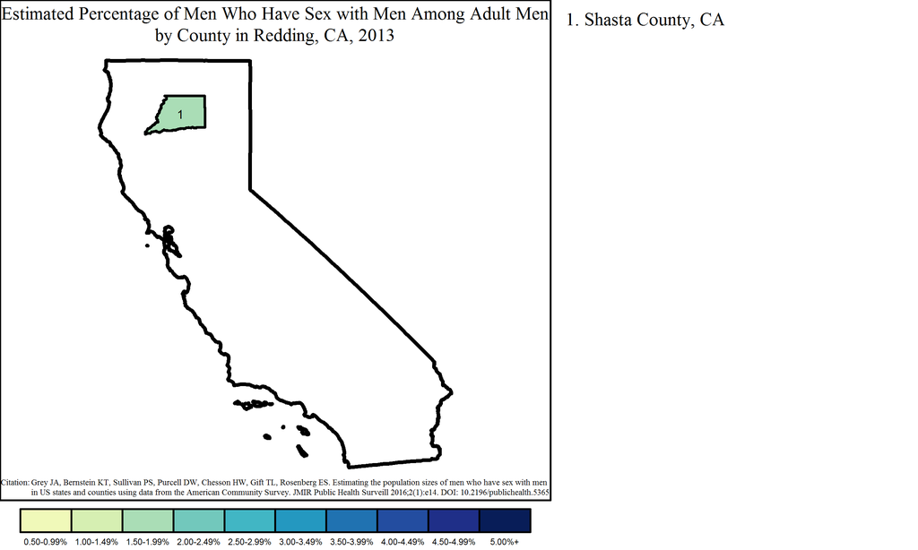

#### El Centro Metropolitan Statistical Area

The El Centro MSA had a population of 1,103 MSM, or 0.1% of all MSM in California. Of the 63,985 adult men in El Centro, an estimated 1.7% were MSM.

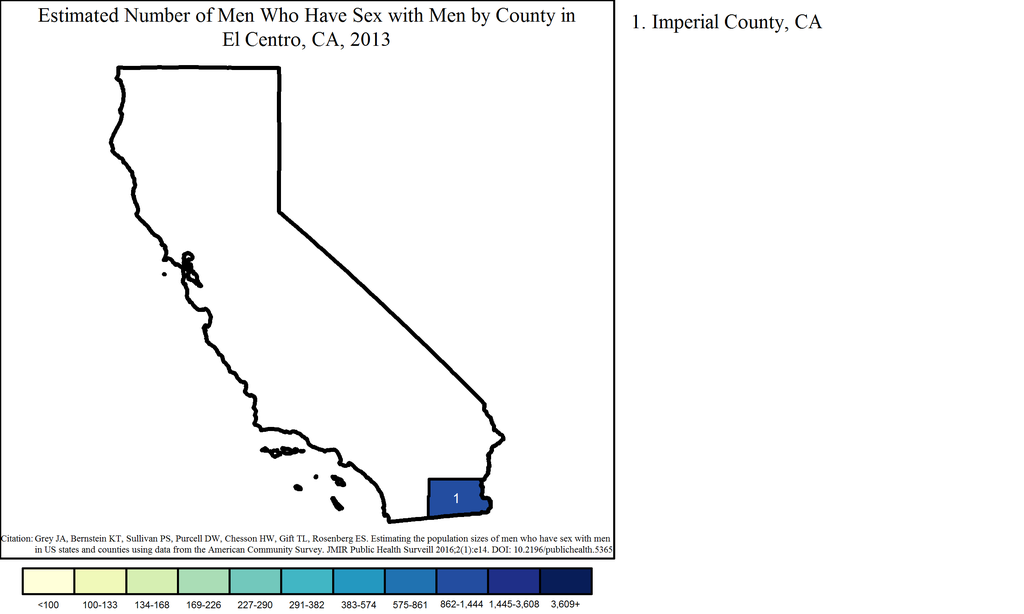

Note: Range cutpoints for the map are based on the distribution of MSM among all counties in the United States.

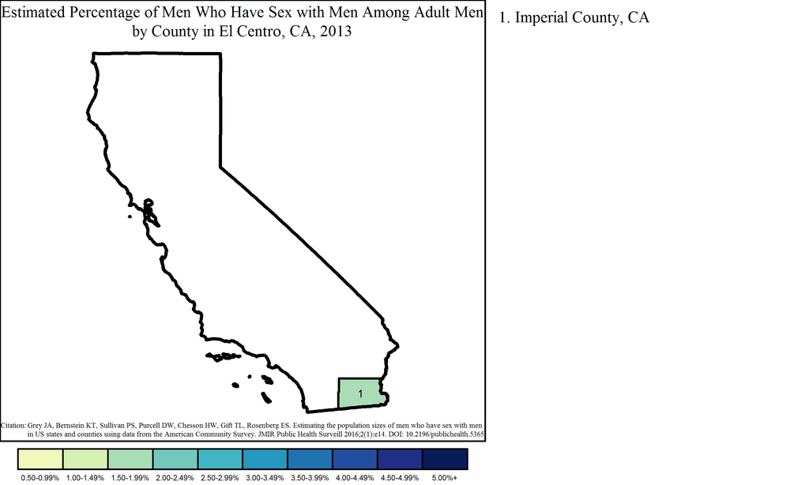

#### Madera Metropolitan Statistical Area

The Madera MSA had a population of 950 MSM, or 0.1% of all MSM in California. Of the 51,378 adult men in Madera, an estimated 1.8% were MSM.

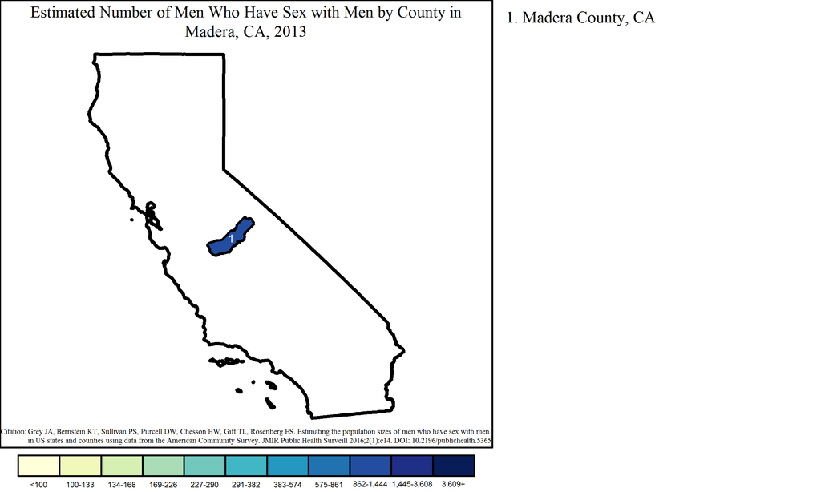

Note: Range cutpoints for the map are based on the distribution of MSM among all counties in the United States.

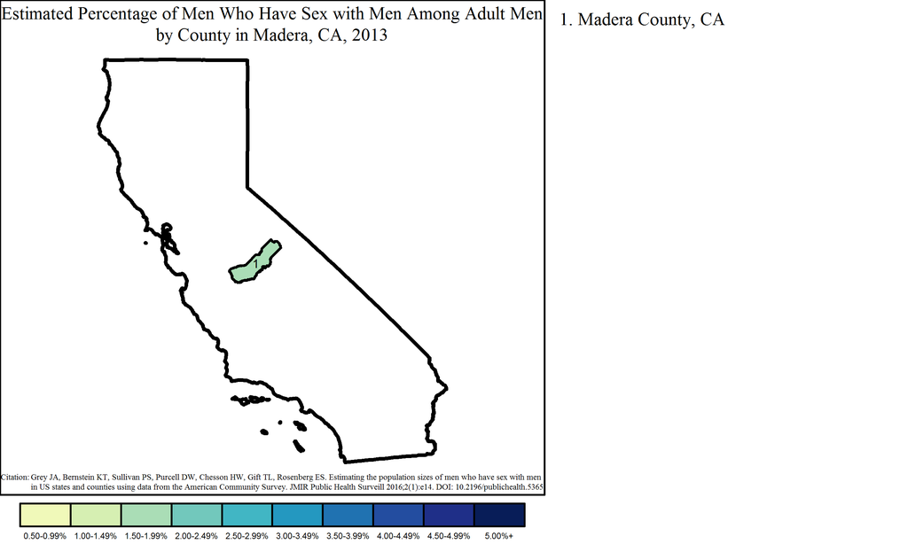